# Risk Factor Analysis

## Outcome Variable

**Outcome Variable:** swasted

## Predictor Variables

**Intervention Variable:** impfloor

**Adjustment Set:**

- arm
- sex
- W_mage
- meducyrs
- feducyrs
- hhwealth_quart
- hfoodsec
- W_mhtcm
- W_mwtkg
- W_mbmi
- W_nrooms
- W_nchldlt5
- W_parity
- impsan
- safeh20
- delta_W_mage
- delta_meducyrs
- delta_feducyrs
- delta_hhwealth_quart
- delta_hfoodsec
- delta_W_mhtcm
- delta_W_mwtkg
- delta_W_mbmi
- delta_W_nrooms
- delta_W_nchldlt5
- delta_W_parity
- delta_impsan
- delta_safeh20

## Stratifying Variables

The analysis was stratified on these variable(s):

- agecat
- studyid
- country

## Data Summary

| agecat | studyid | country | impfloor | swasted | n_cell | n |
| --- | --- | --- | --- | --- | --- | --- |
| Birth | ki0047075b-MAL-ED | BANGLADESH | 1 | 0 | 177 | 201 |
| Birth | ki0047075b-MAL-ED | BANGLADESH | 1 | 1 | 8 | 201 |
| Birth | ki0047075b-MAL-ED | BANGLADESH | 0 | 0 | 16 | 201 |
| Birth | ki0047075b-MAL-ED | BANGLADESH | 0 | 1 | 0 | 201 |
| Birth | ki0047075b-MAL-ED | BRAZIL | 1 | 0 | 55 | 57 |
| Birth | ki0047075b-MAL-ED | BRAZIL | 1 | 1 | 0 | 57 |
| Birth | ki0047075b-MAL-ED | BRAZIL | 0 | 0 | 2 | 57 |
| Birth | ki0047075b-MAL-ED | BRAZIL | 0 | 1 | 0 | 57 |
| Birth | ki0047075b-MAL-ED | INDIA | 1 | 0 | 33 | 39 |
| Birth | ki0047075b-MAL-ED | INDIA | 1 | 1 | 0 | 39 |
| Birth | ki0047075b-MAL-ED | INDIA | 0 | 0 | 6 | 39 |
| Birth | ki0047075b-MAL-ED | INDIA | 0 | 1 | 0 | 39 |
| Birth | ki0047075b-MAL-ED | NEPAL | 1 | 0 | 7 | 24 |
| Birth | ki0047075b-MAL-ED | NEPAL | 1 | 1 | 1 | 24 |
| Birth | ki0047075b-MAL-ED | NEPAL | 0 | 0 | 16 | 24 |
| Birth | ki0047075b-MAL-ED | NEPAL | 0 | 1 | 0 | 24 |
| Birth | ki0047075b-MAL-ED | PERU | 1 | 0 | 37 | 210 |
| Birth | ki0047075b-MAL-ED | PERU | 1 | 1 | 0 | 210 |
| Birth | ki0047075b-MAL-ED | PERU | 0 | 0 | 173 | 210 |
| Birth | ki0047075b-MAL-ED | PERU | 0 | 1 | 0 | 210 |
| Birth | ki0047075b-MAL-ED | SOUTH AFRICA | 1 | 0 | 86 | 95 |
| Birth | ki0047075b-MAL-ED | SOUTH AFRICA | 1 | 1 | 0 | 95 |
| Birth | ki0047075b-MAL-ED | SOUTH AFRICA | 0 | 0 | 9 | 95 |
| Birth | ki0047075b-MAL-ED | SOUTH AFRICA | 0 | 1 | 0 | 95 |
| Birth | ki0047075b-MAL-ED | TANZANIA, UNITED REPUBLIC OF | 1 | 0 | 5 | 111 |
| Birth | ki0047075b-MAL-ED | TANZANIA, UNITED REPUBLIC OF | 1 | 1 | 0 | 111 |
| Birth | ki0047075b-MAL-ED | TANZANIA, UNITED REPUBLIC OF | 0 | 0 | 106 | 111 |
| Birth | ki0047075b-MAL-ED | TANZANIA, UNITED REPUBLIC OF | 0 | 1 | 0 | 111 |
| Birth | ki1000108-CMC-V-BCS-2002 | INDIA | 1 | 0 | 67 | 68 |
| Birth | ki1000108-CMC-V-BCS-2002 | INDIA | 1 | 1 | 1 | 68 |

[output cut: 162 more lines]

The following strata were considered:

- agecat: 24 months, studyid: ki0047075b-MAL-ED, country: BANGLADESH
- agecat: 24 months, studyid: ki0047075b-MAL-ED, country: BRAZIL
- agecat: 24 months, studyid: ki0047075b-MAL-ED, country: INDIA
- agecat: 24 months, studyid: ki0047075b-MAL-ED, country: NEPAL
- agecat: 24 months, studyid: ki0047075b-MAL-ED, country: PERU
- agecat: 24 months, studyid: ki0047075b-MAL-ED, country: SOUTH AFRICA
- agecat: 24 months, studyid: ki0047075b-MAL-ED, country: TANZANIA, UNITED REPUBLIC OF
- agecat: 24 months, studyid: ki1000108-CMC-V-BCS-2002, country: INDIA
- agecat: 24 months, studyid: ki1000108-IRC, country: INDIA
- agecat: 24 months, studyid: ki1017093-NIH-Birth, country: BANGLADESH
- agecat: 24 months, studyid: ki1017093b-PROVIDE, country: BANGLADESH
- agecat: 24 months, studyid: ki1017093c-NIH-Crypto, country: BANGLADESH
- agecat: 24 months, studyid: ki1113344-GMS-Nepal, country: NEPAL
- agecat: 24 months, studyid: ki1114097-CONTENT, country: PERU
- agecat: 24 months, studyid: kiGH5241-JiVitA-3, country: BANGLADESH
- agecat: 24 months, studyid: kiGH5241-JiVitA-4, country: BANGLADESH
- agecat: 6 months, studyid: ki0047075b-MAL-ED, country: BANGLADESH
- agecat: 6 months, studyid: ki0047075b-MAL-ED, country: BRAZIL
- agecat: 6 months, studyid: ki0047075b-MAL-ED, country: INDIA
- agecat: 6 months, studyid: ki0047075b-MAL-ED, country: NEPAL
- agecat: 6 months, studyid: ki0047075b-MAL-ED, country: PERU
- agecat: 6 months, studyid: ki0047075b-MAL-ED, country: SOUTH AFRICA
- agecat: 6 months, studyid: ki0047075b-MAL-ED, country: TANZANIA, UNITED REPUBLIC OF
- agecat: 6 months, studyid: ki1000108-CMC-V-BCS-2002, country: INDIA
- agecat: 6 months, studyid: ki1000108-IRC, country: INDIA
- agecat: 6 months, studyid: ki1017093-NIH-Birth, country: BANGLADESH
- agecat: 6 months, studyid: ki1017093b-PROVIDE, country: BANGLADESH
- agecat: 6 months, studyid: ki1017093c-NIH-Crypto, country: BANGLADESH
- agecat: 6 months, studyid: ki1113344-GMS-Nepal, country: NEPAL
- agecat: 6 months, studyid: ki1114097-CONTENT, country: PERU
- agecat: 6 months, studyid: kiGH5241-JiVitA-3, country: BANGLADESH
- agecat: 6 months, studyid: kiGH5241-JiVitA-4, country: BANGLADESH
- agecat: Birth, studyid: ki0047075b-MAL-ED, country: BANGLADESH
- agecat: Birth, studyid: ki0047075b-MAL-ED, country: BRAZIL
- agecat: Birth, studyid: ki0047075b-MAL-ED, country: INDIA
- agecat: Birth, studyid: ki0047075b-MAL-ED, country: NEPAL
- agecat: Birth, studyid: ki0047075b-MAL-ED, country: PERU
- agecat: Birth, studyid: ki0047075b-MAL-ED, country: SOUTH AFRICA
- agecat: Birth, studyid: ki0047075b-MAL-ED, country: TANZANIA, UNITED REPUBLIC OF
- agecat: Birth, studyid: ki1000108-CMC-V-BCS-2002, country: INDIA
- agecat: Birth, studyid: ki1000108-IRC, country: INDIA
- agecat: Birth, studyid: ki1017093-NIH-Birth, country: BANGLADESH
- agecat: Birth, studyid: ki1017093b-PROVIDE, country: BANGLADESH
- agecat: Birth, studyid: ki1017093c-NIH-Crypto, country: BANGLADESH
- agecat: Birth, studyid: ki1113344-GMS-Nepal, country: NEPAL
- agecat: Birth, studyid: ki1114097-CONTENT, country: PERU
- agecat: Birth, studyid: kiGH5241-JiVitA-3, country: BANGLADESH
- agecat: Birth, studyid: kiGH5241-JiVitA-4, country: BANGLADESH

### Dropped Strata

Some strata were dropped due to rare outcomes:

- agecat: Birth, studyid: ki0047075b-MAL-ED, country: BANGLADESH
- agecat: Birth, studyid: ki0047075b-MAL-ED, country: BRAZIL
- agecat: Birth, studyid: ki0047075b-MAL-ED, country: INDIA
- agecat: Birth, studyid: ki0047075b-MAL-ED, country: NEPAL
- agecat: Birth, studyid: ki0047075b-MAL-ED, country: PERU
- agecat: Birth, studyid: ki0047075b-MAL-ED, country: SOUTH AFRICA
- agecat: Birth, studyid: ki0047075b-MAL-ED, country: TANZANIA, UNITED REPUBLIC OF
- agecat: Birth, studyid: ki1000108-CMC-V-BCS-2002, country: INDIA
- agecat: Birth, studyid: ki1000108-IRC, country: INDIA
- agecat: Birth, studyid: ki1017093-NIH-Birth, country: BANGLADESH
- agecat: Birth, studyid: ki1017093b-PROVIDE, country: BANGLADESH
- agecat: Birth, studyid: ki1113344-GMS-Nepal, country: NEPAL
- agecat: Birth, studyid: ki1114097-CONTENT, country: PERU
- agecat: 6 months, studyid: ki0047075b-MAL-ED, country: BANGLADESH
- agecat: 6 months, studyid: ki0047075b-MAL-ED, country: BRAZIL
- agecat: 6 months, studyid: ki0047075b-MAL-ED, country: INDIA
- agecat: 6 months, studyid: ki0047075b-MAL-ED, country: NEPAL
- agecat: 6 months, studyid: ki0047075b-MAL-ED, country: PERU
- agecat: 6 months, studyid: ki0047075b-MAL-ED, country: SOUTH AFRICA
- agecat: 6 months, studyid: ki0047075b-MAL-ED, country: TANZANIA, UNITED REPUBLIC OF
- agecat: 6 months, studyid: ki1000108-CMC-V-BCS-2002, country: INDIA
- agecat: 6 months, studyid: ki1000108-IRC, country: INDIA
- agecat: 6 months, studyid: ki1017093-NIH-Birth, country: BANGLADESH
- agecat: 6 months, studyid: ki1017093b-PROVIDE, country: BANGLADESH
- agecat: 6 months, studyid: ki1017093c-NIH-Crypto, country: BANGLADESH
- agecat: 6 months, studyid: ki1113344-GMS-Nepal, country: NEPAL
- agecat: 6 months, studyid: ki1114097-CONTENT, country: PERU
- agecat: 6 months, studyid: kiGH5241-JiVitA-4, country: BANGLADESH
- agecat: 24 months, studyid: ki0047075b-MAL-ED, country: BANGLADESH
- agecat: 24 months, studyid: ki0047075b-MAL-ED, country: BRAZIL
- agecat: 24 months, studyid: ki0047075b-MAL-ED, country: INDIA
- agecat: 24 months, studyid: ki0047075b-MAL-ED, country: NEPAL
- agecat: 24 months, studyid: ki0047075b-MAL-ED, country: PERU
- agecat: 24 months, studyid: ki0047075b-MAL-ED, country: SOUTH AFRICA
- agecat: 24 months, studyid: ki0047075b-MAL-ED, country: TANZANIA, UNITED REPUBLIC OF
- agecat: 24 months, studyid: ki1000108-CMC-V-BCS-2002, country: INDIA
- agecat: 24 months, studyid: ki1000108-IRC, country: INDIA
- agecat: 24 months, studyid: ki1017093-NIH-Birth, country: BANGLADESH
- agecat: 24 months, studyid: ki1017093b-PROVIDE, country: BANGLADESH
- agecat: 24 months, studyid: ki1017093c-NIH-Crypto, country: BANGLADESH
- agecat: 24 months, studyid: ki1113344-GMS-Nepal, country: NEPAL
- agecat: 24 months, studyid: ki1114097-CONTENT, country: PERU
- agecat: 24 months, studyid: kiGH5241-JiVitA-4, country: BANGLADESH

## Methods Detail

We’re interested in the causal parameters $E[Y_a]$ for all values of $a \in \mathcal{A}$. These parameters represent the mean outcome if, possibly contrary to fact, we intervened to set all units to have $A=a$. Under the randomization and positivity assumptions, these are identified by the statistical parameters $\psi_a=E_W[E_{Y|A,W}(Y|A=a,W)]$. In addition, we’re interested in the mean of $Y$, $E[Y]$ under no intervention (the observed mean). We will estimate these parameters by using SuperLearner to fit the relevant likelihood factors – $E_{Y|A,W}(Y|A=a,W)$ and $p(A=a|W)$, and then updating our likelihood fit using a joint TMLE.

For unadjusted analyses ($W=\{\}$), initial likelihoods were estimated using Lrnr_glm to estimate the simple $E(Y|A)$ and Lrnr_mean to estimate $p(A)$. For adjusted analyses, a small library containing Lrnr_glmnet, Lrnr_xgboost, and Lrnr_mean was used.

Having estimated these parameters, we will then use the delta method to estimate relative risks and attributable risks relative to a prespecified baseline level of $A$.

# Results Detail

## Results Plots

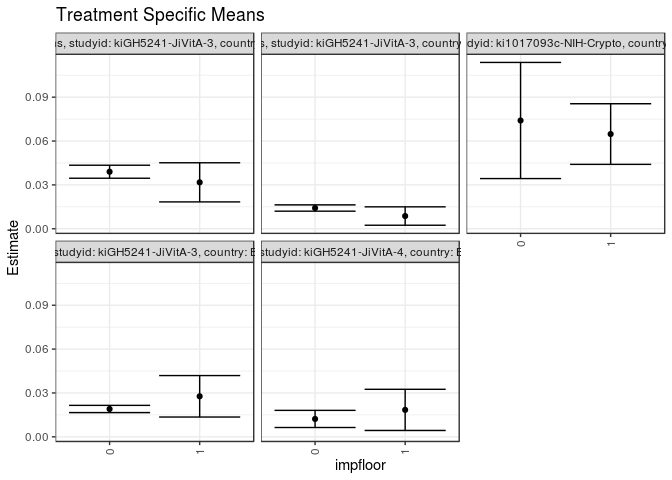

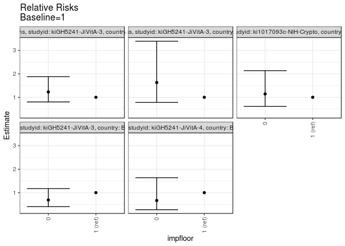

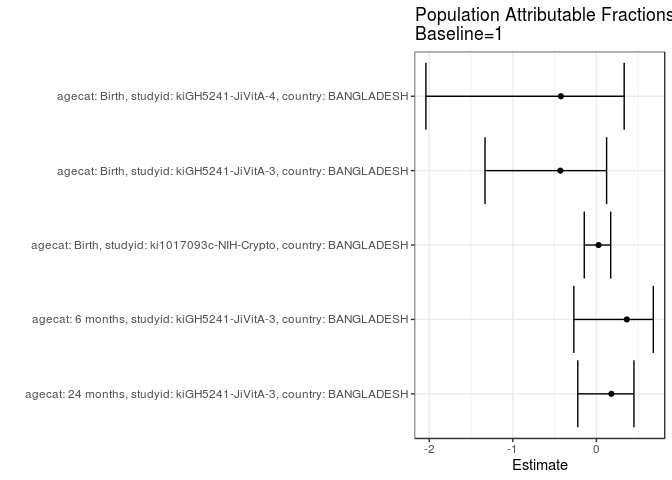

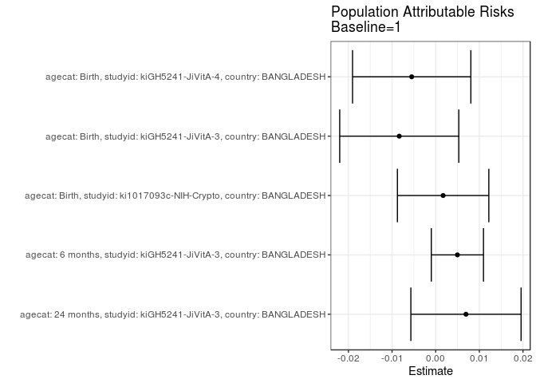

## Results Table

### Parameter: TSM

| agecat | studyid | country | intervention_level | baseline_level | estimate | ci_lower | ci_upper |
| --- | --- | --- | --- | --- | --- | --- | --- |
| Birth | ki1017093c-NIH-Crypto | BANGLADESH | 1 | NA | 0.0647760 | 0.0440441 | 0.0855080 |
| Birth | ki1017093c-NIH-Crypto | BANGLADESH | 0 | NA | 0.0740304 | 0.0343265 | 0.1137344 |
| Birth | kiGH5241-JiVitA-3 | BANGLADESH | 1 | NA | 0.0277233 | 0.0135474 | 0.0418991 |
| Birth | kiGH5241-JiVitA-3 | BANGLADESH | 0 | NA | 0.0190604 | 0.0165918 | 0.0215291 |
| Birth | kiGH5241-JiVitA-4 | BANGLADESH | 1 | NA | 0.0184502 | 0.0043706 | 0.0325298 |
| Birth | kiGH5241-JiVitA-4 | BANGLADESH | 0 | NA | 0.0122468 | 0.0063846 | 0.0181090 |
| 6 months | kiGH5241-JiVitA-3 | BANGLADESH | 1 | NA | 0.0087036 | 0.0024139 | 0.0149933 |
| 6 months | kiGH5241-JiVitA-3 | BANGLADESH | 0 | NA | 0.0141909 | 0.0120355 | 0.0163462 |
| 24 months | kiGH5241-JiVitA-3 | BANGLADESH | 1 | NA | 0.0317539 | 0.0183724 | 0.0451354 |
| 24 months | kiGH5241-JiVitA-3 | BANGLADESH | 0 | NA | 0.0390058 | 0.0345633 | 0.0434484 |

### Parameter: E(Y)

| agecat | studyid | country | intervention_level | baseline_level | estimate | ci_lower | ci_upper |
| --- | --- | --- | --- | --- | --- | --- | --- |
| Birth | ki1017093c-NIH-Crypto | BANGLADESH | NA | NA | 0.0664781 | 0.0481022 | 0.0848539 |
| Birth | kiGH5241-JiVitA-3 | BANGLADESH | NA | NA | 0.0193699 | 0.0169591 | 0.0217808 |
| Birth | kiGH5241-JiVitA-4 | BANGLADESH | NA | NA | 0.0129490 | 0.0075258 | 0.0183723 |
| 6 months | kiGH5241-JiVitA-3 | BANGLADESH | NA | NA | 0.0136749 | 0.0116007 | 0.0157492 |
| 24 months | kiGH5241-JiVitA-3 | BANGLADESH | NA | NA | 0.0386946 | 0.0343662 | 0.0430231 |

### Parameter: RR

| agecat | studyid | country | intervention_level | baseline_level | estimate | ci_lower | ci_upper |
| --- | --- | --- | --- | --- | --- | --- | --- |
| Birth | ki1017093c-NIH-Crypto | BANGLADESH | 1 | 1 | 1.0000000 | 1.0000000 | 1.000000 |
| Birth | ki1017093c-NIH-Crypto | BANGLADESH | 0 | 1 | 1.1428676 | 0.6117430 | 2.135123 |
| Birth | kiGH5241-JiVitA-3 | BANGLADESH | 1 | 1 | 1.0000000 | 1.0000000 | 1.000000 |
| Birth | kiGH5241-JiVitA-3 | BANGLADESH | 0 | 1 | 0.6875249 | 0.4027746 | 1.173585 |
| Birth | kiGH5241-JiVitA-4 | BANGLADESH | 1 | 1 | 1.0000000 | 1.0000000 | 1.000000 |
| Birth | kiGH5241-JiVitA-4 | BANGLADESH | 0 | 1 | 0.6637777 | 0.2691163 | 1.637214 |
| 6 months | kiGH5241-JiVitA-3 | BANGLADESH | 1 | 1 | 1.0000000 | 1.0000000 | 1.000000 |
| 6 months | kiGH5241-JiVitA-3 | BANGLADESH | 0 | 1 | 1.6304535 | 0.7837146 | 3.392024 |
| 24 months | kiGH5241-JiVitA-3 | BANGLADESH | 1 | 1 | 1.0000000 | 1.0000000 | 1.000000 |
| 24 months | kiGH5241-JiVitA-3 | BANGLADESH | 0 | 1 | 1.2283799 | 0.8024131 | 1.880474 |

### Parameter: PAR

| agecat | studyid | country | intervention_level | baseline_level | estimate | ci_lower | ci_upper |
| --- | --- | --- | --- | --- | --- | --- | --- |
| Birth | ki1017093c-NIH-Crypto | BANGLADESH | 1 | NA | 0.0017020 | -0.0087731 | 0.0121771 |
| Birth | kiGH5241-JiVitA-3 | BANGLADESH | 1 | NA | -0.0083533 | -0.0219995 | 0.0052928 |
| Birth | kiGH5241-JiVitA-4 | BANGLADESH | 1 | NA | -0.0055011 | -0.0190592 | 0.0080570 |
| 6 months | kiGH5241-JiVitA-3 | BANGLADESH | 1 | NA | 0.0049713 | -0.0010081 | 0.0109507 |
| 24 months | kiGH5241-JiVitA-3 | BANGLADESH | 1 | NA | 0.0069408 | -0.0056905 | 0.0195720 |

### Parameter: PAF

| agecat | studyid | country | intervention_level | baseline_level | estimate | ci_lower | ci_upper |
| --- | --- | --- | --- | --- | --- | --- | --- |
| Birth | ki1017093c-NIH-Crypto | BANGLADESH | 1 | NA | 0.0256030 | -0.1452319 | 0.1709545 |
| Birth | kiGH5241-JiVitA-3 | BANGLADESH | 1 | NA | -0.4312534 | -1.3328815 | 0.1219072 |
| Birth | kiGH5241-JiVitA-4 | BANGLADESH | 1 | NA | -0.4248304 | -2.0400920 | 0.3322105 |
| 6 months | kiGH5241-JiVitA-3 | BANGLADESH | 1 | NA | 0.3635324 | -0.2698516 | 0.6809934 |
| 24 months | kiGH5241-JiVitA-3 | BANGLADESH | 1 | NA | 0.1793725 | -0.2226563 | 0.4492078 |